## Loading and Preparing data;

```r
getwd()
```

```
## [1] "C:/Users/sk_mi/Desktop/Coursera/Reproducible Research"
```

```r
mydata<- read.csv("C:/Users/sk_mi/Desktop/Coursera/Reproducible Research/week 2/repdata%2Fdata%2Factivity/activity.csv")
str(mydata)
```

```
## 'data.frame':    17568 obs. of  3 variables:
##  $ steps   : int  NA NA NA NA NA NA NA NA NA NA ...
##  $ date    : Factor w/ 61 levels "2012-10-01","2012-10-02",..: 1 1 1 1 1 1 1 1 1 1 ...
##  $ interval: int  0 5 10 15 20 25 30 35 40 45 ...
```

```r
head(mydata)
```

```
##   steps       date interval
## 1    NA 2012-10-01        0
## 2    NA 2012-10-01        5
## 3    NA 2012-10-01       10
## 4    NA 2012-10-01       15
## 5    NA 2012-10-01       20
## 6    NA 2012-10-01       25
```

```r
tail(mydata)
```

```
##       steps       date interval
## 17563    NA 2012-11-30     2330
## 17564    NA 2012-11-30     2335
## 17565    NA 2012-11-30     2340
## 17566    NA 2012-11-30     2345
## 17567    NA 2012-11-30     2350
## 17568    NA 2012-11-30     2355
```

## What is mean total number of steps taken per day?;

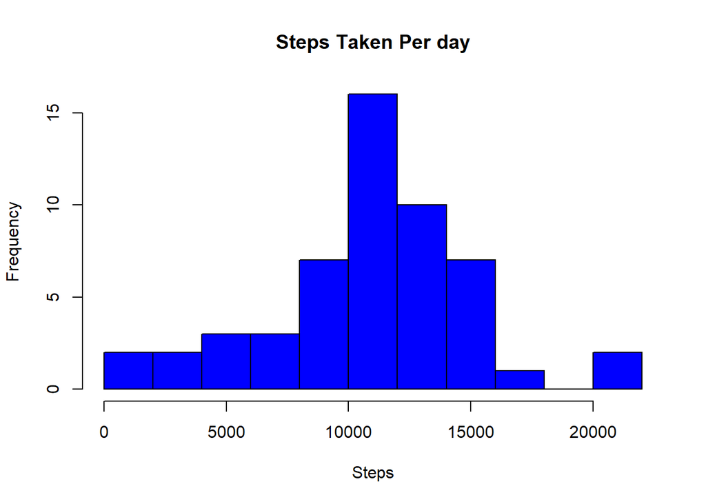

```r
steps_perday<- aggregate(steps~date, mydata, sum)
hist(steps_perday$steps, main = "Steps Taken Per day", xlab = "Steps", col = "blue", breaks = 8)
```

## Let’s find the mean and median of the total no of steps;

```r
meansteps_perday<- mean(steps_perday$steps)
mediansteps_perday<- median(steps_perday$steps)
print(meansteps_perday)
```

```
## [1] 10766.19
```

```r
print(mediansteps_perday)
```

```
## [1] 10765
```

### Note: As we can see mean and median are both pretty much close to each other, this is how we can sense the average value of mydata.

## What is the average daily activity pattern?;

### by anwering this question, we will accomplished two below statement;

- We will make a time series plot of the 5-minute interval (x-axis) and the average number of steps taken, averaged across all days (y-axis) *Which 5-minute interval, on average across all the days in the dataset, contains the maximum number of steps?

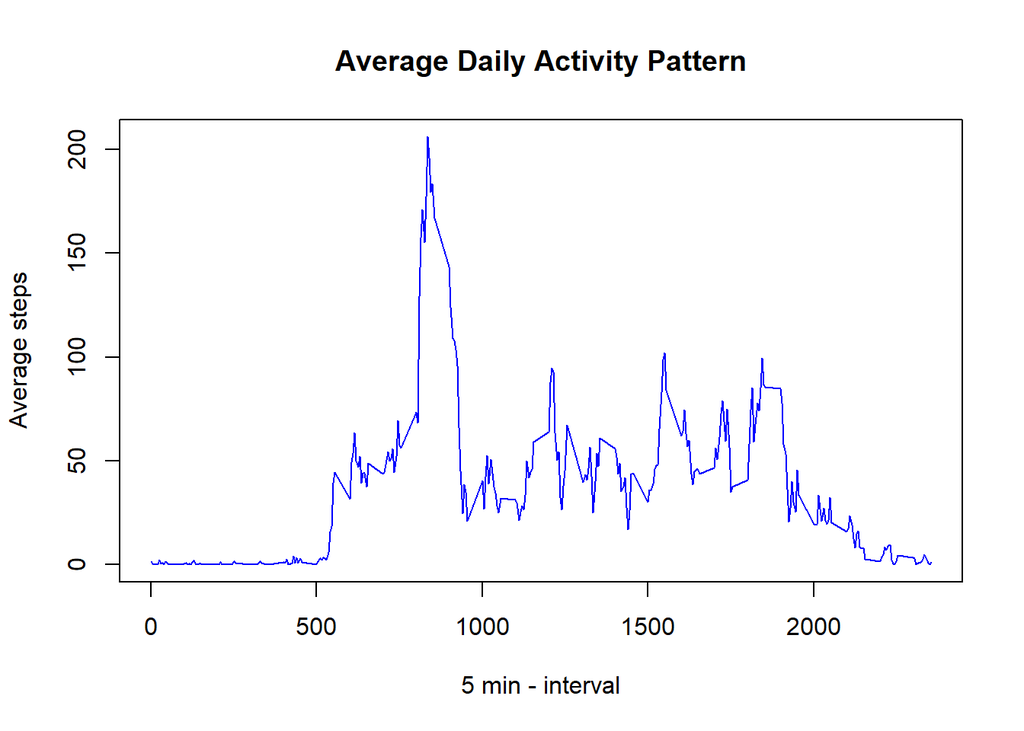

```r
steps_interval<- aggregate(steps ~ interval, mydata, mean)
plot(steps_interval$interval, steps_interval$steps, type="l", xlab = "5 min - interval", ylab = "Average steps", main = "Average Daily Activity Pattern", col = "blue")
```

```r
steps_interval$interval[which.max(steps_interval$steps)]
```

```
## [1] 835
```

## Imputing missing values;

Note that there are a number of days/intervals where there are missing values (coded as NA). The presence of missing days may introduce bias into some calculations or summaries of the data.

### We will calculate the total number of missing values in the dataset;

```r
nrow(mydata[is.na(mydata$steps),])
```

```
## [1] 2304
```

### Now we will devise a “strategy” for filling in all of the missing values in the dataset;

```r
newdata_withoutNAs<- mydata
newdata_withoutNAs[is.na(newdata_withoutNAs$steps), "steps"]<- 0 ## Putting na = 0
```

As we have already replaced NA with numeric data 0;

### Now will create histogram of the total number of steps taken each day;

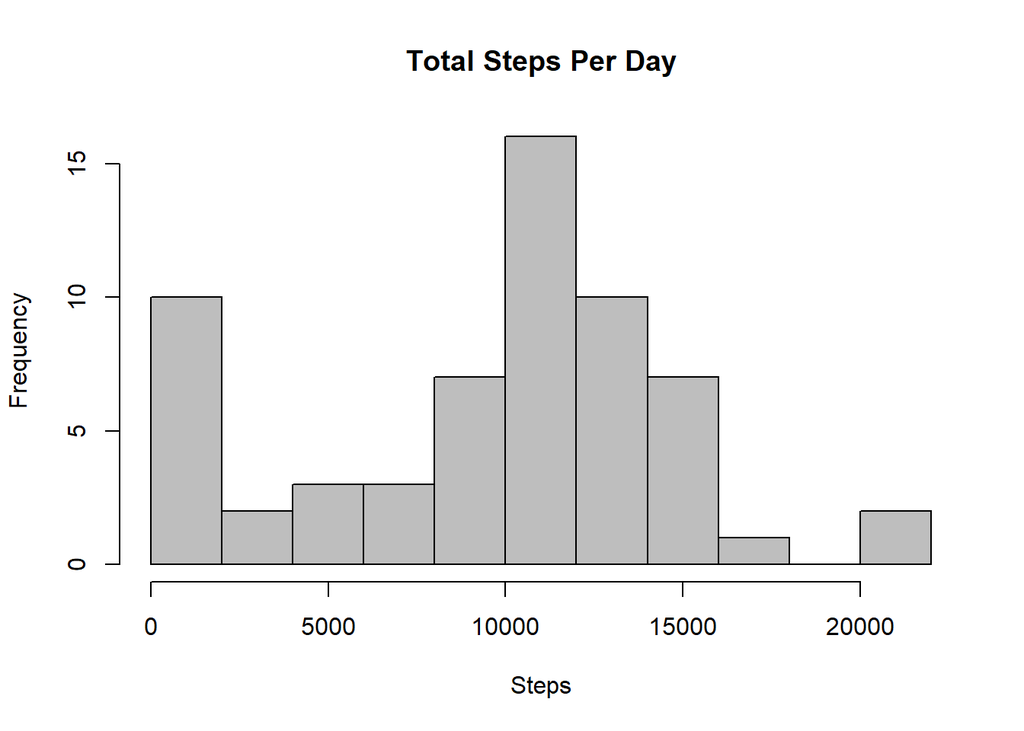

```r
steps_perday_withoutNAs<- aggregate(steps ~ date, newdata_withoutNAs, sum)

hist(steps_perday_withoutNAs$steps, main = "Total Steps Per Day", xlab = "Steps", col = "grey", breaks = 10)
```

### and Calculate and report the mean and median total number of steps taken per day;

```r
meansteps_perday_withoutNAs<- mean(steps_perday_withoutNAs$steps)
mediansteps_perday_withoutNAs<- median(steps_perday_withoutNAs$steps)
print(meansteps_perday_withoutNAs)  # mean
```

```
## [1] 9354.23
```

```r
print(mediansteps_perday_withoutNAs)  # median
```

```
## [1] 10395
```

## Are there differences in activity patterns between weekdays and weekends?;

Now we are going to create a new factor variable in the dataset with two levels - “weekday” and “weekend” indicating whether a given date is a weekday or weekend day.

```r
newdata_withoutNAs$day=ifelse(as.POSIXlt(as.Date(newdata_withoutNAs$date))$wday%%6==0,"weekend","weekday")
newdata_withoutNAs$daytype=factor(newdata_withoutNAs$day,levels=c("weekday","weekend"))
```

### finally now will create a panel plot containing a time series plot (i.e. type = “l”) of the 5-minute interval (x-axis) and the average number of steps taken, averaged across all weekday days or weekend days (y-axis).;

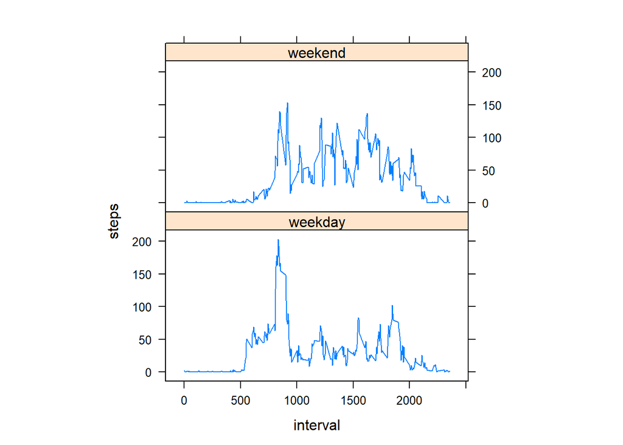

```r
stepsInterval2=aggregate(steps~interval+day,newdata_withoutNAs,mean)
library(lattice)
xyplot(steps~interval|factor(day),data=stepsInterval2,aspect=1/2,type="l")
```